# Lab 8 draft

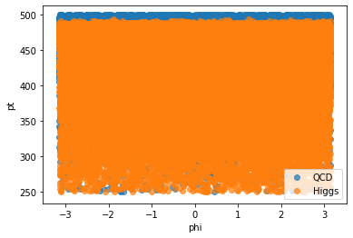

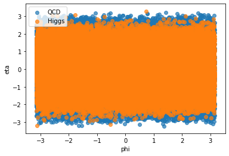

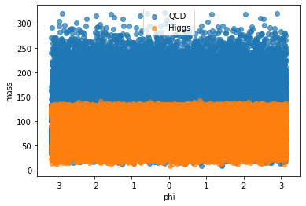

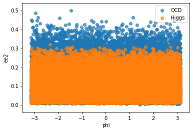

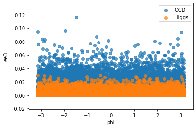

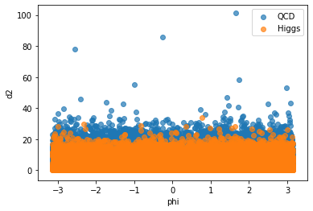

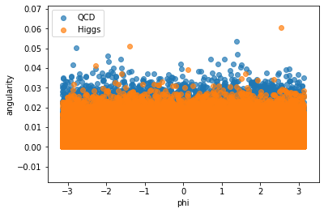

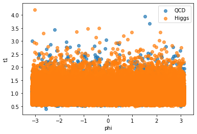

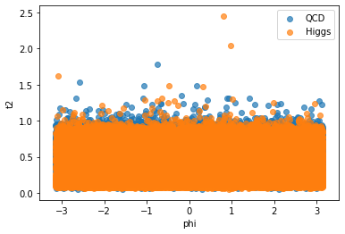

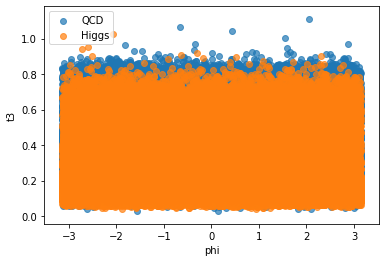

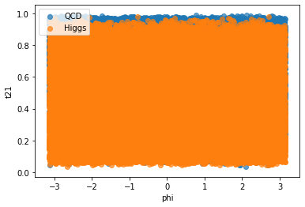

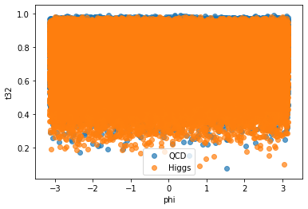

[1 more figures not shown]

```python
titles = ['Transverse Momentum','Pseudorapidity','Azimuthal Angle','Invariant Mass',
          '2-Point ECF Ratio','3-Point ECF Ratio','3-to-2 Point ECF Ratio',
         'Angularity','t1','t2','t3','t21','t32','ktDeltaR']


for i in keys:

    if i != 'phi':

        qcd = qcd_dict[i]
        higgs = higgs_dict[i]
        figure()
        plt.scatter(qcd_dict['phi'],qcd,label = 'QCD',alpha = 0.7)
        plt.scatter(higgs_dict['phi'],higgs,label = 'Higgs',alpha = 0.7)
        plt.legend()
        plt.ylabel(i)
        plt.xlabel('phi')



plt.show()
```

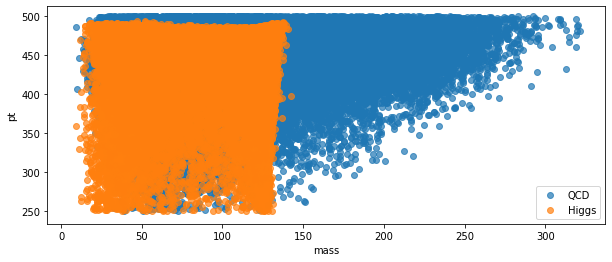

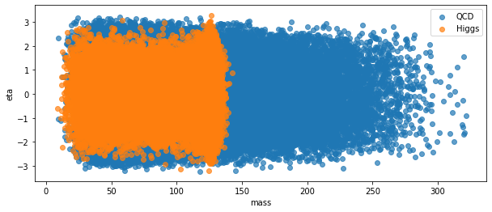

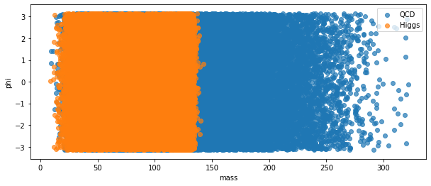

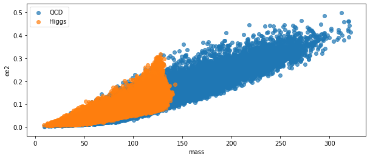

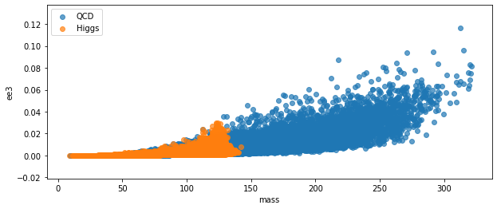

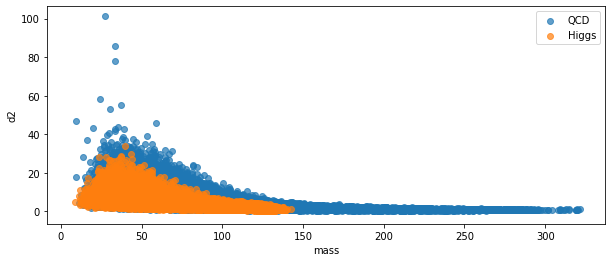

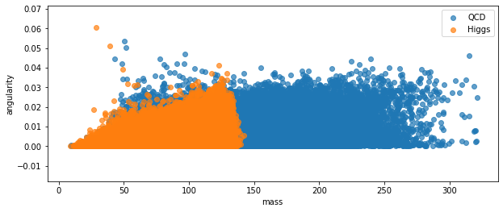

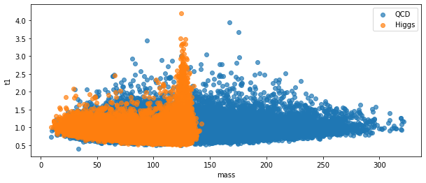

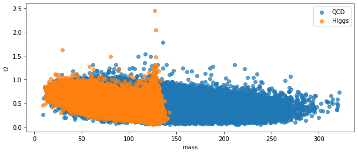

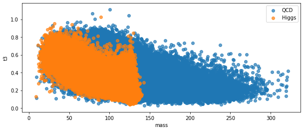

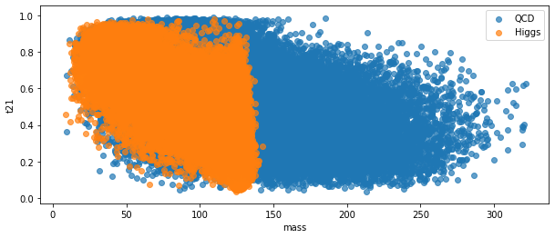

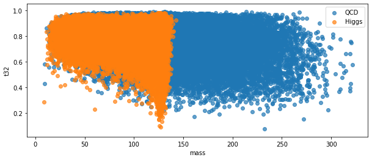

[1 more figures not shown]

```python
titles = ['Transverse Momentum','Pseudorapidity','Azimuthal Angle','Invariant Mass',
          '2-Point ECF Ratio','3-Point ECF Ratio','3-to-2 Point ECF Ratio',
         'Angularity','t1','t2','t3','t21','t32','ktDeltaR']


# Keys = Index(['pt', 'eta', 'phi', 'mass', 'ee2', 'ee3', 'd2', 'angularity', 't1',
#        't2', 't3', 't21', 't32', 'KtDeltaR'],
#       dtype='object')


for i in keys:

    if i != 'mass':

        qcd = qcd_dict[i]
        higgs = higgs_dict[i]
        figure()
        plt.scatter(qcd_dict['mass'],qcd,label = 'QCD',alpha = 0.7)
        plt.scatter(higgs_dict['mass'],higgs,label = 'Higgs',alpha = 0.7)
        plt.legend()
        plt.ylabel(i)
        plt.xlabel('mass')



plt.show()

# figure(figsize = (20,15))
# plt.scatter(qcd_dict['phi'],qcd_dict['mass'],label = 'qcd',alpha = 0.7)
# plt.scatter(higgs_dict['phi'],higgs_dict['mass'],label = 'higgs',alpha = 0.7)
# plt.xlabel('phi')
# plt.ylabel('mass')
# plt.legend()

# plt.show()
```

Looks like we can cut data for mass >= 150:

```python
!jupyter nbconvert --to html Phys434_thalyapaleologu_lab7_modifiedlab5.ipynb
```

```
[NbConvertApp] Converting notebook Phys434_thalyapaleologu_lab7_modifiedlab5.ipynb to html
[NbConvertApp] Writing 2199334 bytes to Phys434_thalyapaleologu_lab7_modifiedlab5.html
```

```python
#calculate significance before cut

#calculate signal mean
higgsmassmean = np.mean(higgs_dict['mass'])
#calculate back mean
qcdmassmean = np.mean(qcd_dict['mass'])

#assume poisson back
#signal like is high mass
probability = 1 - stats.poisson.cdf(higgsmassmean,mu = qcdmassmean)
significance = stats.norm.ppf(1 - probability)

print(significance)
```

```
1.6666117786402679
```

```python
#Throw out values ABOVE THRESHOLD; KEEP VALUES BELOW THRESHOLD
def keepIndiciesBelowBound(array,threshold):
    indicies = np.array([])

    for i in range(len(array)):
        if array[i] <= threshold:
            indicies = np.append(indicies,i)


    return indicies
```

```python
#KEEPING VALUES BELOW THRESHOLD; DEFINE SIGNAL AS HIGH MASS

threshold = 100
while threshold <= 200:
    qcdmassindicies = keepIndiciesBelowBound(qcd_dict['mass'],threshold)
    higgsmassindicies = keepIndiciesBelowBound(higgs_dict['mass'],threshold)

    newhiggsmass = higgs_dict['mass']
    newhiggsmass = newhiggsmass[higgsmassindicies]

    newqcdmass = qcd_dict['mass']
    newqcdmass = newqcdmass[qcdmassindicies]

    newhiggsmassmean = np.mean(newhiggsmass)
    newqcdmassmean = np.mean(newqcdmass)

    probability = 1 - stats.poisson.cdf(newhiggsmassmean,mu = newqcdmassmean)
    significance = stats.norm.ppf(1 - probability)

    print("significance for threshold = ",threshold," is ", significance)

    threshold = threshold + 20
```

```
significance for threshold =  100  is  -1.4789257361710968
significance for threshold =  120  is  -0.24876993262207878
significance for threshold =  140  is  3.263373080199145
significance for threshold =  160  is  2.7832742250304943
significance for threshold =  180  is  2.4188733891873038
significance for threshold =  200  is  2.1368556549414315
```

zoom in around 140:

```python
#KEEPING VALUES BELOW THRESHOLD; DEFINE SIGNAL AS HIGH MASS

threshold = 135
while threshold <= 145:
    qcdmassindicies = keepIndiciesRevised(qcd_dict['mass'],threshold)
    higgsmassindicies = keepIndiciesRevised(higgs_dict['mass'],threshold)

    newhiggsmass = higgs_dict['mass']
    newhiggsmass = newhiggsmass[higgsmassindicies]

    newqcdmass = qcd_dict['mass']
    newqcdmass = newqcdmass[qcdmassindicies]

    newhiggsmassmean = np.mean(newhiggsmass)
    newqcdmassmean = np.mean(newqcdmass)

    probability = 1 - stats.poisson.cdf(newhiggsmassmean,mu = newqcdmassmean)
    significance = stats.norm.ppf(1 - probability)

    print("significance for threshold = ",threshold," is ", significance)

    threshold = threshold + 2
```

```
significance for threshold =  135  is  3.4042317826998802
significance for threshold =  137  is  3.3452668702700588
significance for threshold =  139  is  3.292355673788938
significance for threshold =  141  is  3.2387919153918725
significance for threshold =  143  is  3.187187577631689
significance for threshold =  145  is  3.1345189331048102
```

zoom in around 135:

```python
#KEEPING VALUES BELOW THRESHOLD; DEFINE SIGNAL AS HIGH MASS

threshold = 125
while threshold <= 135:
    qcdmassindicies = keepIndiciesRevised(qcd_dict['mass'],threshold)
    higgsmassindicies = keepIndiciesRevised(higgs_dict['mass'],threshold)

    newhiggsmass = higgs_dict['mass']
    newhiggsmass = newhiggsmass[higgsmassindicies]

    newqcdmass = qcd_dict['mass']
    newqcdmass = newqcdmass[qcdmassindicies]

    newhiggsmassmean = np.mean(newhiggsmass)
    newqcdmassmean = np.mean(newqcdmass)

    probability = 1 - stats.poisson.cdf(newhiggsmassmean,mu = newqcdmassmean)
    significance = stats.norm.ppf(1 - probability)

    print("significance for threshold = ",threshold," is ", significance)

    threshold = threshold + 2
```

```
significance for threshold =  125  is  1.9840769481023692
significance for threshold =  127  is  3.4494576564692787
significance for threshold =  129  is  3.5847590903523026
significance for threshold =  131  is  3.522749055556654
significance for threshold =  133  is  3.4632111682565183
significance for threshold =  135  is  3.4042317826998802
```

zoom in around 129:

```python
#KEEPING VALUES BELOW THRESHOLD; DEFINE SIGNAL AS HIGH MASS

threshold = 128
while threshold <= 131:
    qcdmassindicies = keepIndiciesRevised(qcd_dict['mass'],threshold)
    higgsmassindicies = keepIndiciesRevised(higgs_dict['mass'],threshold)

    newhiggsmass = higgs_dict['mass']
    newhiggsmass = newhiggsmass[higgsmassindicies]

    newqcdmass = qcd_dict['mass']
    newqcdmass = newqcdmass[qcdmassindicies]

    newhiggsmassmean = np.mean(newhiggsmass)
    newqcdmassmean = np.mean(newqcdmass)

    probability = 1 - stats.poisson.cdf(newhiggsmassmean,mu = newqcdmassmean)
    significance = stats.norm.ppf(1 - probability)

    print("significance for threshold = ",threshold," is ", significance)

    threshold = threshold + 0.5
```

```
significance for threshold =  128  is  3.5165331422219426
significance for threshold =  128.5  is  3.5002872271605607
significance for threshold =  129.0  is  3.5847590903523026
significance for threshold =  129.5  is  3.5677107464705986
significance for threshold =  130.0  is  3.555074667942496
significance for threshold =  130.5  is  3.538760495498159
significance for threshold =  131.0  is  3.522749055556654
```

It seems that mass = 129 is the best threshold to cut at, with a resulting significance of 3.58

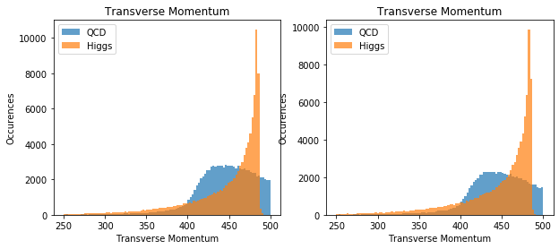

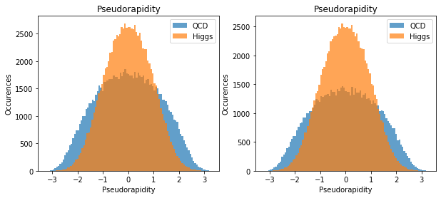

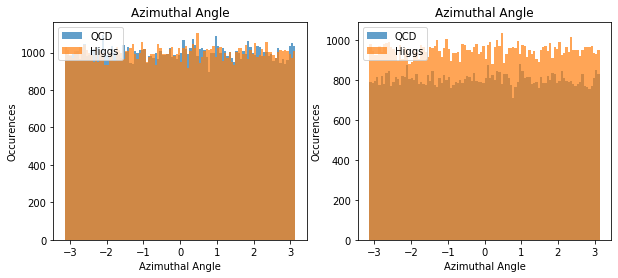

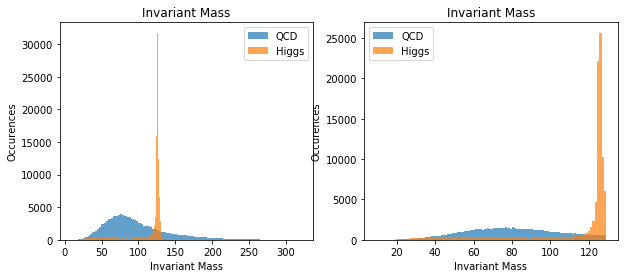

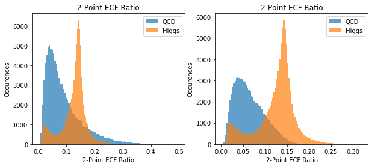

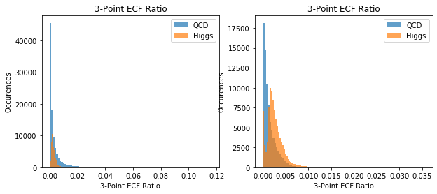

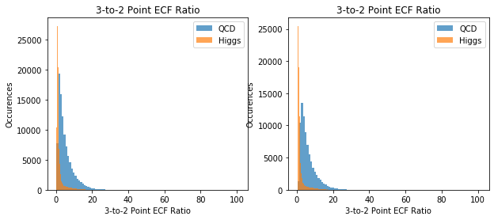

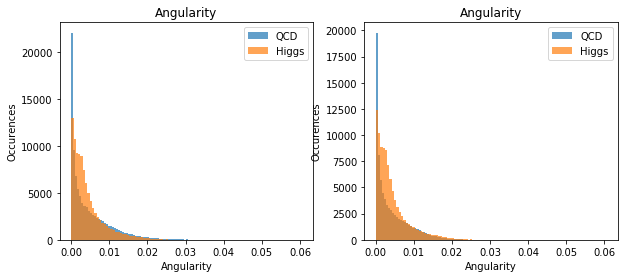

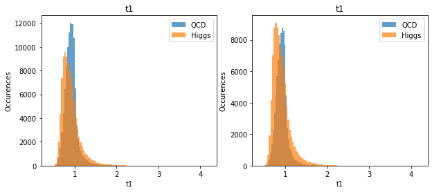

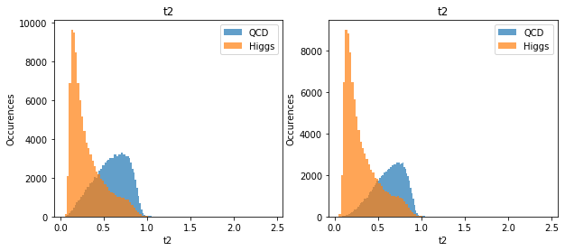

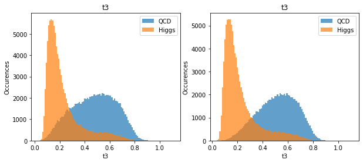

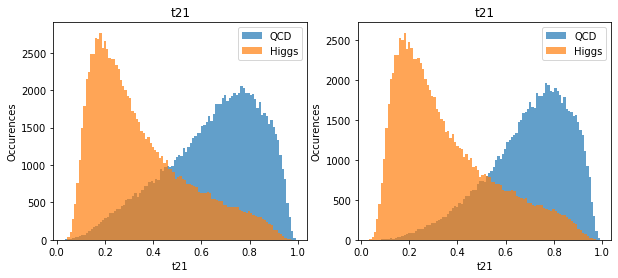

[2 more figures not shown]

```python
titles = ['Transverse Momentum','Pseudorapidity','Azimuthal Angle','Invariant Mass',
          '2-Point ECF Ratio','3-Point ECF Ratio','3-to-2 Point ECF Ratio',
         'Angularity','t1','t2','t3','t21','t32','ktDeltaR']


qcdmassindicies = keepIndiciesBelowBound(qcd_dict['mass'],129)
higgsmassindicies = keepIndiciesBelowBound(higgs_dict['mass'],129)

j = 0
for i in keys:

    figure()

    plt.subplot(1,2,1)
    qcd = qcd_dict[i]
    higgs = higgs_dict[i]

    plt.title(titles[j])
    plt.xlabel(titles[j])
    plt.ylabel('Occurences')
    plt.hist(qcd,100,label = 'QCD',alpha = 0.7)
    plt.hist(higgs,100,label = 'Higgs',alpha = 0.7)
    plt.legend()

    plt.subplot(1,2,2)
    newqcd = qcd[qcdmassindicies]
    newhiggs = higgs[higgsmassindicies]

    plt.title(titles[j])
    plt.xlabel(titles[j])
    plt.ylabel('Occurences')
    plt.hist(newqcd,100,label = 'QCD',alpha = 0.7)
    plt.hist(newhiggs,100,label = 'Higgs',alpha = 0.7)
    plt.legend()




    j = j+1

plt.show()
```

let's look at what happens when we scatter plot with 2 point ecf ratio as x axis:

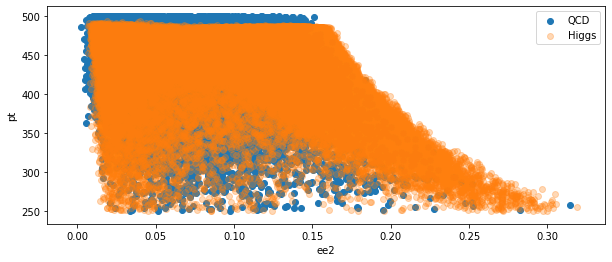

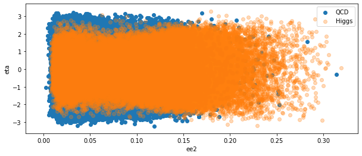

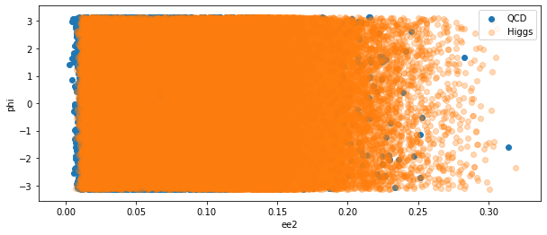

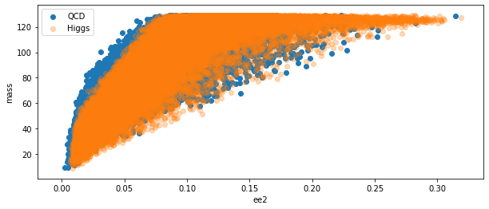

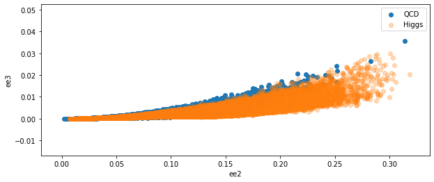

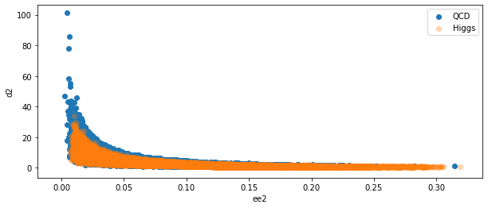

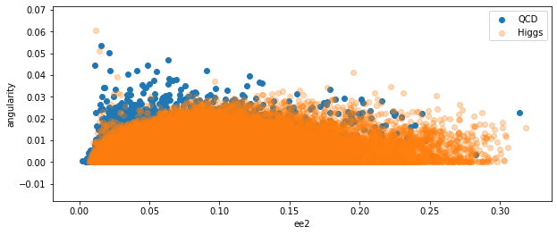

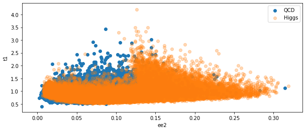

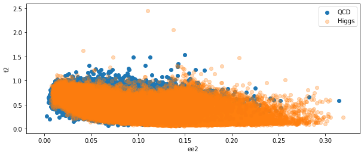

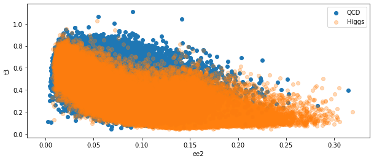

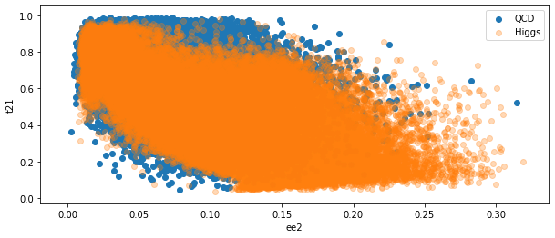

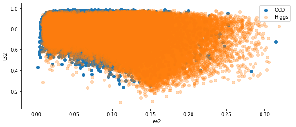

[1 more figures not shown]

```python
qcdee2 = qcd_dict['ee2']
qcdee2 = qcdee2[qcdmassindicies]

higgsee2 = higgs_dict['ee2']
higgsee2 = higgsee2[higgsmassindicies]

for i in keys:

    if i != 'ee2':

        qcd = qcd_dict[i]
        qcd = qcd[qcdmassindicies]

        higgs = higgs_dict[i]
        higgs = higgs[higgsmassindicies]

        figure()
        plt.scatter(qcdee2,qcd,label = 'QCD',alpha = 1)
        plt.scatter(higgsee2,higgs,label = 'Higgs',alpha = 0.3)
        plt.legend()
        plt.ylabel(i)
        plt.xlabel('ee2')



plt.show()
```

```python
#Throw out values BELOW THRESHOLD; KEEP VALUES ABOVE THRESHOLD
def keepIndiciesAboveBound(array,threshold):
    indicies = np.array([])

    for i in range(len(array)):
        if array[i] >= threshold:
            indicies = np.append(indicies,i)


    return indicies
```

```python
qcdmasscut_dict = qcd_dict
higgsmasscut_dict = higgs_dict

for i in keys:
    qcd = qcd_dict[i]
    qcd = qcd[qcdmassindicies]

    higgs = higgs_dict[i]
    higgs = higgs[higgsmassindicies]

    qcdmasscut_dict[i] = qcd
    higgsmasscut_dict[i] = higgs
```

```python
#KEEPING VALUES ABOVE THRESHOLD for ee2
#define high ee2 signal

threshold = 0.0
while threshold <= 0.03:
    qcdee2indicies = keepIndiciesAboveBound(qcdmasscut_dict['ee2'],threshold)
    higgsee2indicies = keepIndiciesAboveBound(higgsmasscut_dict['ee2'],threshold)

#     #newhiggsmass = higgsmasscut_dict['mass']
#     newhiggsmass = newhiggsmass[higgsee2indicies]

#     newqcdmass = qcdmasscut_dict['mass']
#     newqcdmass = newqcdmass[qcdee2indicies]

#     newhiggsmassmean = np.mean(newhiggsmass)
#     newqcdmassmean = np.mean(newqcdmass)

#     probability = 1 - stats.poisson.cdf(newhiggsmassmean,mu = newqcdmassmean)
#     significance = stats.norm.ppf(1 - probability)

    newhiggsee2 = higgsmasscut_dict['ee2']
    newhiggsee2 = newhiggsee2[higgsee2indicies]

    newqcdee2 = qcdmasscut_dict['ee2']
    newqcdee2 = newqcdee2[qcdee2indicies]

    newhiggsee2mean = np.mean(newhiggsee2)
    newqcdee2mean = np.mean(newqcdee2)

    probability = 1 - stats.poisson.cdf(newhiggsee2mean,mu = newqcdee2mean)
    significance = stats.norm.ppf(1 - probability)

    print("significance for threshold = ",threshold," is ", significance)

    threshold = threshold + 0.005
```

```
significance for threshold =  0.0  is  1.5346036647696082
significance for threshold =  0.005  is  1.5345750195872543
significance for threshold =  0.01  is  1.5336345418143744
significance for threshold =  0.015  is  1.5269363155238622
significance for threshold =  0.02  is  1.5138224552925976
significance for threshold =  0.025  is  1.4968926048692548
```

zoom in around 0.05

```python
#KEEPING VALUES ABOVE THRESHOLD for ee2
#define high mass signal

threshold = 0.02
while threshold <= 0.07:
    qcdee2indicies = keepIndiciesAboveBound(qcdmasscut_dict['ee2'],threshold)
    higgsee2indicies = keepIndiciesAboveBound(higgsmasscut_dict['ee2'],threshold)

    newhiggsmass = higgsmasscut_dict['mass']
    newhiggsmass = newhiggsmass[higgsee2indicies]

    newqcdmass = qcdmasscut_dict['mass']
    newqcdmass = newqcdmass[qcdee2indicies]

    newhiggsmassmean = np.mean(newhiggsmass)
    newqcdmassmean = np.mean(newqcdmass)

    probability = 1 - stats.poisson.cdf(newhiggsmassmean,mu = newqcdmassmean)
    significance = stats.norm.ppf(1 - probability)

    print("significance for threshold = ",threshold," is ", significance)

    threshold = threshold + 0.01
```

```
significance for threshold =  0.02  is  3.5101942686331635
significance for threshold =  0.03  is  3.289224071270076
significance for threshold =  0.04  is  3.030977365566443
significance for threshold =  0.05  is  2.680888656563785
significance for threshold =  0.060000000000000005  is  2.354282635526962
significance for threshold =  0.07  is  2.0481316872523063
```

```python
#KEEPING VALUES ABOVE THRESHOLD for ee2
#define high mass signal

threshold = 0.01
while threshold <= 0.03:
    qcdee2indicies = keepIndiciesAboveBound(qcdmasscut_dict['ee2'],threshold)
    higgsee2indicies = keepIndiciesAboveBound(higgsmasscut_dict['ee2'],threshold)

    newhiggsmass = higgsmasscut_dict['mass']
    newhiggsmass = newhiggsmass[higgsee2indicies]

    newqcdmass = qcdmasscut_dict['mass']
    newqcdmass = newqcdmass[qcdee2indicies]

    newhiggsmassmean = np.mean(newhiggsmass)
    newqcdmassmean = np.mean(newqcdmass)

    probability = 1 - stats.poisson.cdf(newhiggsmassmean,mu = newqcdmassmean)
    significance = stats.norm.ppf(1 - probability)

    print("significance for threshold = ",threshold," is ", significance)

    threshold = threshold + 0.005
```

```
significance for threshold =  0.01  is  3.5699382374955193
significance for threshold =  0.015  is  3.477923063472272
significance for threshold =  0.02  is  3.5101942686331635
significance for threshold =  0.025  is  3.4109090436939913
```

```python
#KEEPING VALUES ABOVE THRESHOLD for ee2
#define high mass signal

threshold = 0.0
while threshold <= 0.015:
    qcdee2indicies = keepIndiciesAboveBound(qcdmasscut_dict['ee2'],threshold)
    higgsee2indicies = keepIndiciesAboveBound(higgsmasscut_dict['ee2'],threshold)

    newhiggsmass = higgsmasscut_dict['mass']
    newhiggsmass = newhiggsmass[higgsee2indicies]

    newqcdmass = qcdmasscut_dict['mass']
    newqcdmass = newqcdmass[qcdee2indicies]

    newhiggsmassmean = np.mean(newhiggsmass)
    newqcdmassmean = np.mean(newqcdmass)

    probability = 1 - stats.poisson.cdf(newhiggsmassmean,mu = newqcdmassmean)
    significance = stats.norm.ppf(1 - probability)

    print("significance for threshold = ",threshold," is ", significance)

    threshold = threshold + 0.0025
```

```
significance for threshold =  0.0  is  3.5847590903523026
significance for threshold =  0.0025  is  3.5846538630040516
significance for threshold =  0.005  is  3.5842770181159676
significance for threshold =  0.0075  is  3.5815730242014485
significance for threshold =  0.01  is  3.5699382374955193
significance for threshold =  0.0125  is  3.5355831212473676
```

Let's look at t3 below 0.6:

```python
#KEEPING VALUES below THRESHOLD for t3
#define high mass signal

threshold = 0.3
while threshold <= 0.8:
    qcdt3indicies = keepIndiciesBelowBound(qcdmasscut_dict['t3'],threshold)
    higgst3indicies = keepIndiciesBelowBound(higgsmasscut_dict['t3'],threshold)

    newhiggsmass = higgsmasscut_dict['mass']
    newhiggsmass = newhiggsmass[higgst3indicies]

    newqcdmass = qcdmasscut_dict['mass']
    newqcdmass = newqcdmass[qcdt3indicies]

    newhiggsmassmean = np.mean(newhiggsmass)
    newqcdmassmean = np.mean(newqcdmass)

    probability = 1 - stats.poisson.cdf(newhiggsmassmean,mu = newqcdmassmean)
    significance = stats.norm.ppf(1 - probability)

    print("significance for threshold = ",threshold," is ", significance)

    threshold = threshold + 0.1
```

```
significance for threshold =  0.3  is  2.305759697621042
significance for threshold =  0.4  is  2.6679880972833674
significance for threshold =  0.5  is  3.0003561031488504
significance for threshold =  0.6  is  3.20997426920972
significance for threshold =  0.7  is  3.392879276936152
significance for threshold =  0.7999999999999999  is  3.5691738418469727
```

```python
print(pseudoexphigh)
```

```
               pt       eta       phi        mass       ee2       ee3  \
0      491.273762  0.885859 -1.607844   58.540714  0.027848  0.000236
1      443.077741 -0.850850 -1.808610  109.261432  0.111414  0.003361
2      487.700656 -0.848095  3.101697   80.398065  0.059299  0.000973
3      474.234962  1.501633 -1.656456   90.085535  0.061264  0.001368
4      485.597724  1.021424  1.742641  119.889999  0.133209  0.003223
5      484.346573  1.729109  0.035582   56.169632  0.025060  0.000191
6      498.613692  0.339143  0.428245  117.652426  0.061328  0.001783
7      456.277049  0.508332 -2.764901   51.127785  0.035752  0.000297
8      425.838811  0.532726 -1.844972   49.522013  0.022802  0.000167
9      425.280009 -1.450360 -2.319702  140.386827  0.179422  0.007274
10     496.436534 -1.434758  2.927813   76.189395  0.041354  0.000566
11     478.292487 -1.590181 -2.832918   72.831262  0.042418  0.000561
12     450.474934 -1.717658 -3.020256   79.106619  0.063298  0.000923
13     400.217629  1.692700 -1.030404  139.231655  0.175896  0.005473
```

[output cut: 175 more lines]

```python
#print(pseudoexphigh['pt'])
pt = pseudoexphigh['pt']
pt[0]
```

```
491.2737621330417
```

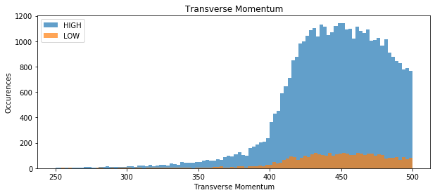

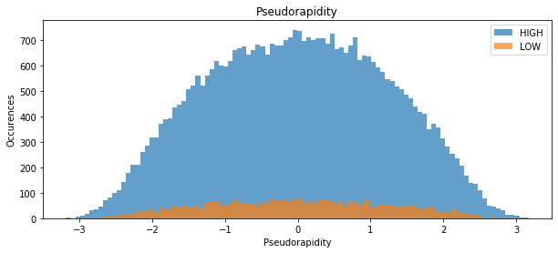

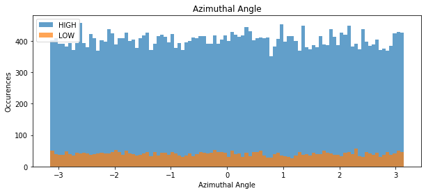

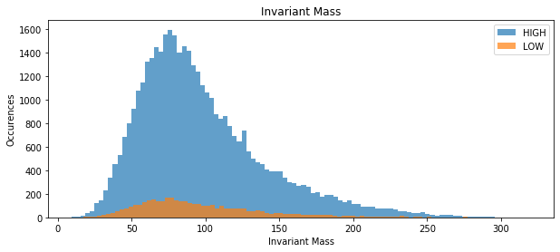

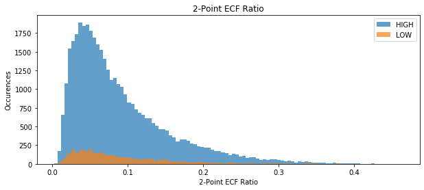

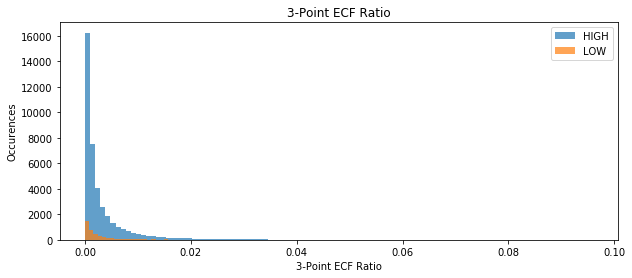

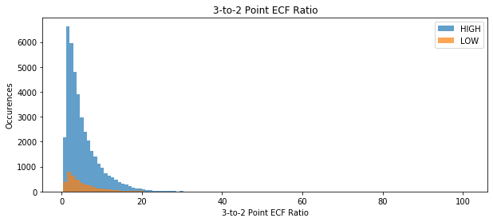

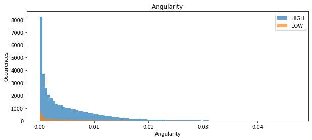

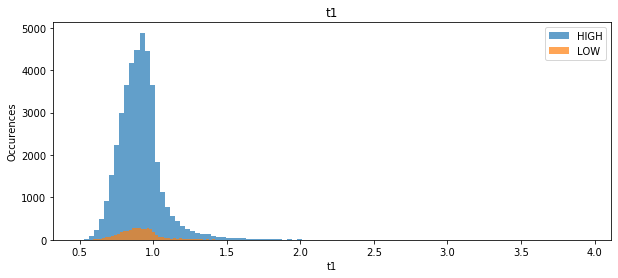

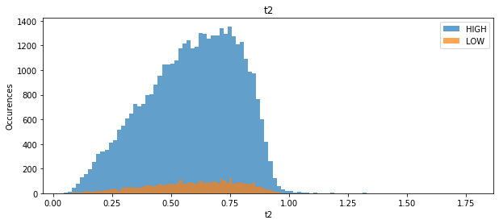

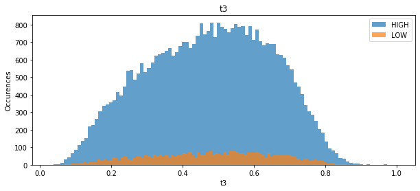

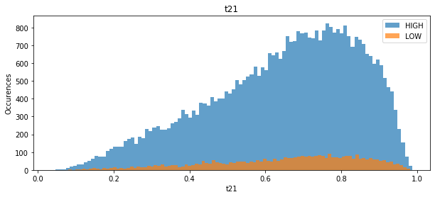

[2 more figures not shown]

```python
titles = ['Transverse Momentum','Pseudorapidity','Azimuthal Angle','Invariant Mass',
          '2-Point ECF Ratio','3-Point ECF Ratio','3-to-2 Point ECF Ratio',
         'Angularity','t1','t2','t3','t21','t32','ktDeltaR']

j = 0
for i in keys:
    high = pseudoexphigh[i]
    low = pseudoexplow[i]
    figure()
    plt.title(titles[j])
    plt.xlabel(titles[j])
    plt.ylabel('Occurences')
    plt.hist(high,100,label = 'HIGH',alpha = 0.7)
    plt.hist(low,100,label = 'LOW',alpha = 0.7)
    plt.legend()
    j = j+1

plt.show()
```

```python
print(pseudoexplow)
```

```
              pt       eta       phi        mass       ee2       ee3  \
0     499.974801 -0.340430 -3.124063   35.763836  0.016922  0.000061
1     470.525978  1.447995 -0.463162   79.069978  0.052447  0.000801
2     455.009985 -1.672870 -2.260314   56.401982  0.030301  0.000229
3     387.414081 -1.002107 -2.688377   77.412447  0.092790  0.001888
4     442.472789 -1.103515 -2.367580   86.479013  0.049532  0.000909
5     435.186386  2.409175  1.596414   95.730849  0.063901  0.001591
6     365.663450  0.064420  0.416881   97.653679  0.105246  0.004069
7     431.887077  0.597283 -0.140031   78.237299  0.061639  0.001312
8     348.822134  0.736982  2.092074  145.561760  0.257727  0.021457
9     473.859950 -0.356456 -1.550095   81.911007  0.068672  0.001177
10    464.207347  0.462262  2.945248   70.801958  0.057248  0.000662
11    356.614062  0.326346 -1.994250  154.179911  0.239536  0.020701
12    431.132669  0.607916  2.587338   89.222423  0.059954  0.001294
13    438.995891 -1.724626  0.329372   92.614403  0.075625  0.001918
```

[output cut: 175 more lines]

```python
!jupyter nbconvert --Phys434_thalyapaleologu_lab8_modifiedlab7.ipynb
```